# Assessing the relationship between living standards and chronic asthma

Eleanor Harrison

November 23 2024

# Introduction

Asthma is a common condition worldwide that can be caused by prolonged indoor exposure to mold (World Health Organization, 2024; Mousavi, 2016). Currently, there is a lack of accurate data on the prevalence of mold in social housing, potentially making this issue more serious than expected (The Scottish Parliament, 2023).

As individual deprivation has been reported to have a negative affect on health-related qualty of life, this exploratory data analysis aims investigate whether living standards could have an impact on the prevalence of chronic asthma (Kashem et al., 2019). To do this, living standards will be defined by SIMD due to the association of social housing with mold and poor ventilation, and prevalence of chronic asthma will be measured by the number of prescriptions of drugs used in common preventer inhalers as these are often prescribed when long or short acting bronchodilators are ineffective, suggesting severe chronic asthma.

## Data chosen for Analysis

**SIMD**

SIMD Data is released every 4 years, the dataset used will be the most recent data from 2020 (Public Health Scotland: https://www.opendata.nhs.scot/dataset/scottish-index-of-multiple-deprivation/resource/acade396-8430-4b34-895a-b3e757fa346e)

**Prescriptions**

The prescriptions assessed are those for salbutamol, beclometasone, ciclesonide, fluticasone and mometasone as they are the most commonly prescribed drugs used in preventative inhalers (Vincent, 2024)

Prescriptions data used will be *all* months from 2020 to correspond with SIMD year in order to accurately compare the two (Public Health Scotland: https://www.opendata.nhs.scot/dataset/prescriptions-in-the-community)

**GP Practices**

Data on GP Practices was also taken from 2020 to ensure datazone areas were up to date (Public Health Scotland: https://www.opendata.nhs.scot/dataset/gp-practice-contact-details-and-list-sizes/resource/42391720-7dcb-48a2-8070-b9d63b246ac6)

GP Practice Shapefile Data was extracted from Spatial Hub with the locations updated as of 2020 (https://data.spatialhub.scot/dataset/gp_practices-is/resource/8389fd1d-563d-4c05-9833-26d9f07fd6cd)

GP Practice Healthboard Shapefile was extracted from spatialdata.gov.scot (https://spatialdata.gov.scot/geonetwork/srv/eng/catalog.search#/metadata/f12c3826-4b4b-40e6-bf4f-77b9ed01dc14)

## Loading Datasets

```r
#data is organised in 1 main folder withe the R Project
#folder includes 2 subfolders, one for documents ("docs" - rmd and html), and the other with data ("data" - all files used to obtain data), including a sub-sub folder called "files" which contains all prescriptions data to load in with map function

#loading datasets with desired variables selected
#some variables have been renamed for continuity between datasets
#clean names also used for continuity
simd2020 <- read_csv(here("data/simd2020.csv")) %>%
  clean_names() %>%
  select(data_zone, simd2020v2country_decile) %>%
  mutate(simd2020v2country_decile = as.factor(simd2020v2country_decile))

gp_practices <- read_csv(here("data/practice_contactdetails_oct2020-open-data.csv")) %>%
  rename(practice_name = GPPracticeName) %>%
  clean_names() %>%
  select(practice_code, data_zone, hb, practice_list_size, practice_name, gp_cluster, postcode)

#prescriptions data taken from jan-dec 2020,
files <- list.files(here("data", "data_2020"), pattern = "csv")
all_prescriptions_2020 <- files %>%
  map_dfr(~read_csv(here("data", "data_2020", .)))

# filtering prescriptions for desired drugs and selecting desired columns
inhaler_prescriptions <- all_prescriptions_2020 %>%
  rename(HB = HBT) %>%
  rename(practice_code = GPPractice) %>%
  clean_names() %>%
  select(practice_code, bnf_item_description, number_of_paid_items)%>%
  filter(str_detect(bnf_item_description, "SALBUTAMOL|BECLOMETASONE|CICLESONIDE|FLUTICASONE|MOMETASONE"))
```

# Comparison of Prescriptions per GP Practice by SIMD

The three datasets used for this analysis (GP practice, SIMD and Prescriptions data) differ by the variables used for location markers therefore cannot be joined by a common factor. Therefore SIMD and GP data sets will be joined by data zone, and GP and prescriptions data sets will be joined by practice code (this is under the assumption that the practice is in the datazone). The SIMDs of the populations analysed are hence determined by the location of the GP practice that they are patients of. Residuals represent the number of prescriptions per person per GP Practice.

```r
#joining prescriptions, SIMD and GP datasets
prescriptions_gp_join <- left_join(inhaler_prescriptions, gp_practices)
simd_prescriptions_gp_join <- full_join(prescriptions_gp_join, simd2020)

# new variable is created calculating the number of combined prescriptions per person per GP practice to use as comparative residuals in analysis
prescriptions_pp_analysis <-  simd_prescriptions_gp_join %>%
  group_by(practice_name) %>%
  summarise(prescriptions_pp_pgp = sum(number_of_paid_items)/max(practice_list_size), simd2020v2country_decile = first(simd2020v2country_decile), gp_cluster = first(gp_cluster),
    .groups = 'drop')
```

### Figure 1

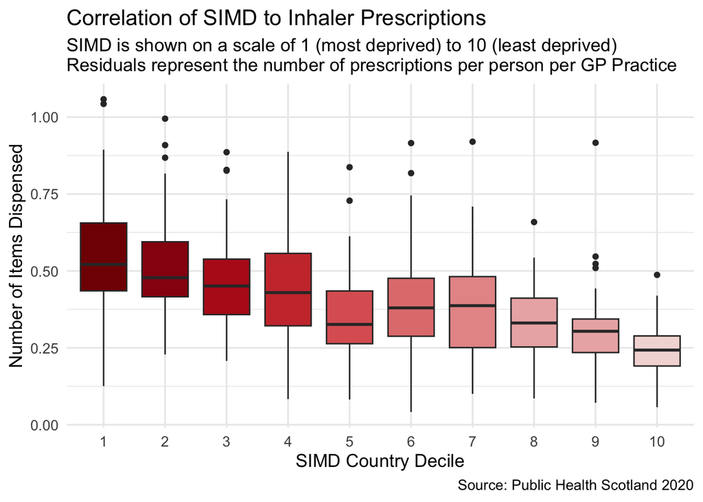

```r
prescriptions_pp_analysis %>%
# Some practice codes are dummy practice codes, therefore don't have an associated with SIMD. Data therefore cannot be analysed so is removed removed
# Homeless Health and Resource Services was the only significant  outlier (in SIMD group 4), as it is not representative of the SIMD of patients it has been removed
  filter(simd2020v2country_decile != "NA", practice_name != "Homeless Health & Resource Services") %>%
# SIMD decile is used in analysis as it shows the most variation between groups (rather than quintile) so patterns will be easier to visualise
  ggplot(aes(x = simd2020v2country_decile, y = prescriptions_pp_pgp, fill = simd2020v2country_decile)) +
  geom_boxplot() +
  scale_fill_manual(values = c("1" = "#820202", "2" = "#981313", "3" = "#B71D1D", "4" = "#CC3939", "5" = "#DD6262", "6" = "#E27E7E", "7" = "#E79797", "8" = "#EBB3B3", "9" = "#EBB3B3", "10" = "#F3DBD8" )) +
  guides(fill="none") +
  labs(
    x = "SIMD Country Decile",
    y = "Number of Items Dispensed",
    title = "Correlation of SIMD to Inhaler Prescriptions",
    subtitle = "SIMD is shown on a scale of 1 (most deprived) to 10 (least deprived)
Residuals represent the number of prescriptions per person per GP Practice",
    caption = "Source: Public Health Scotland 2020"
  ) +
  theme_minimal(base_size = 13)
```

Figure 1 shows that there is a general negative trend in SIMD to number of prescriptions per person. This data aligns with our initial hypothesis that living standards could be negatively affecting instances of chronic asthma.

# Geographical Analysis

In order to explore this relationship further, we can evaluate data on a geographical level. Qualitative analysis can be done to assess the average number of prescriptions per health board whilst looking at the SIMD of individual GP practices within them. This is shown in Figure 2.

### Figure 2

```r
# reading gp gractice location shapefile
gp_practice_shp <- st_read(here("data", "pub_gpprac.shp"), quiet = TRUE) %>%
  clean_names() %>%
  select(postcode, geometry)

#extracting postcodes as common factor between datasets
gp_postcodes <- gp_practices %>%
  select(practice_name, postcode, gp_cluster, hb)

#giving each gp practice its postcode
gp_simd_postcodes <- full_join(prescriptions_pp_analysis, gp_postcodes)

#combining data with shapefile
gp_simd_point_shp <- left_join(gp_practice_shp, gp_simd_postcodes, relationship = "many-to-many") %>%
  filter(!is.na(simd2020v2country_decile))

#reading health board file and changing variable names for continuity
healthboard_shp <- st_read(here("data", "NHS_healthboards_2019.shp"), quiet = TRUE) %>%
  clean_names() %>%
  rename(hb = hb_code)

#creating a summary of prescriptions per health board
healthboard_summary <- gp_simd_postcodes %>%
    group_by(hb) %>%
  summarise(prescriptions_pp_phb = mean(prescriptions_pp_pgp, na.rm = TRUE), simd2020v2country_decile = first(simd2020v2country_decile))

#joining summary data with shapefile
healthboard_analysis_shp <- full_join(healthboard_summary, healthboard_shp)
```

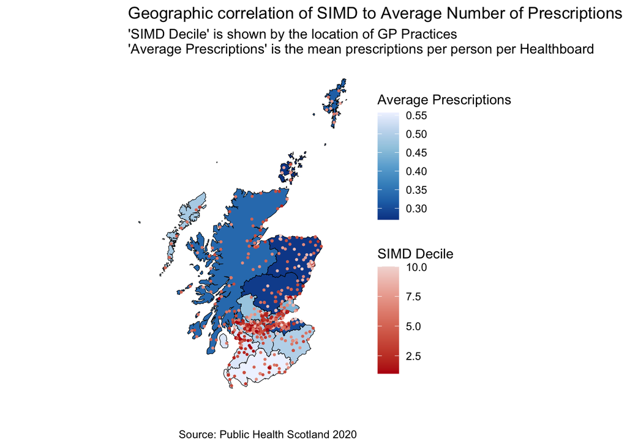

```r
#creating an overlay of GP SIMDs against health board average prescriptions
ggplot() +
  geom_sf(data = healthboard_analysis_shp, aes(fill = prescriptions_pp_phb, geometry = geometry), color = "black", size = 0.1) +
  geom_point(data = gp_simd_point_shp, aes(x = st_coordinates(geometry)[, 1],
                                           y = st_coordinates(geometry)[, 2],
                                           color = as.numeric(simd2020v2country_decile)),
             size = 0.5) +
  scale_fill_distiller(name = "Average Prescriptions") +
  scale_color_gradient(low = "#B81010",
                       high = "#F3DBD8",
                       name = "SIMD Decile") +
    labs(
    title = "Geographic correlation of SIMD to Average Number of Prescriptions",
    subtitle = "'SIMD Decile' is shown by the location of GP Practices
'Average Prescriptions' is the mean prescriptions per person per Healthboard",
    caption = "Source: Public Health Scotland 2020",
    x = "",
    y = ""
    ) +
  theme_minimal() +
  theme(
    panel.grid.major = element_blank(),
    panel.grid.minor = element_blank(),
    axis.text = element_blank(),
    axis.ticks = element_blank()
  )
```

# Resource Allocation

Personalised Asthma Action Plans (PAAPs) are written guides that help patients with Asthma manage their condition with personal instructions in how to respond to different situations. These are very helpful for patients with chronic asthma, but they require a lot training to implement them and a lot of time to put them together. By assessing which GP practices have the most cases per person, resources could be better allocated to give the most affected people PAAPs, through methods such as increased GP and nurse training.

### Figure 3

```r
#creating a table by extracting GP Practice with the highest prescriptions per person rates
prescriptions_pp_analysis %>%
  slice_max(prescriptions_pp_pgp, n = 12) %>%
  select(practice_name, gp_cluster, prescriptions_pp_pgp, simd2020v2country_decile) %>%
  gt() %>%
  tab_header(title ="GP Practices with the Highest Prescription Rates for Preventative Inhalers in Scotland",
             subtitle = "Data from Public Health Scotland (2020)") %>%
  cols_label(practice_name = md("**Practice Name**"),
             gp_cluster = md("**GP Cluster**"),
             prescriptions_pp_pgp = md("**Prescriptions Per Person**"),
             simd2020v2country_decile = md("**SIMD**")) %>%
    cols_align(align = "center",
             columns = c(prescriptions_pp_pgp, simd2020v2country_decile)) %>%
  fmt_number(columns = prescriptions_pp_pgp, decimals = 2) %>%
  tab_style(
    style = cell_fill(color = "#E27E7E"),
    locations = cells_body(
      rows = practice_name %in% c("Homeless Health & Resource Services",
                                  "Challenging Behaviour General Practice",
                                  "Challenging Behaviour Practice"))
  )
```

GP Practices with the Highest Prescription Rates for Preventative Inhalers in Scotland

Data from Public Health Scotland (2020)

| **Practice Name** | **GP Cluster** | **Prescriptions Per Person** | **SIMD** |
| --- | --- | --- | --- |
| Homeless Health & Resource Services | Greater Glasgow & Clyde Undefined | 3.38 | 4 |
| Dr M Duffy & Dr A Morgan | NW - Drumchapel and Yoker | 1.06 | 1 |
| Dalmarnock Family Medical Practice | NE - Bridgeton | 1.04 | 1 |
| Drs Mccallum, Gardiner & Makun | NE - Parkhead / Cranhill | 0.99 | 2 |
| Coatbank Medical Practice | Coatbridge | 0.92 | 7 |
| Challenging Behaviour General Practice | Edinburgh South East - North | 0.92 | 9 |
| Gallowhill Medical Centre | Larkhall/Stonehouse | 0.92 | 6 |
| Dr K Miller & Partners | NE - Parkhead / Cranhill | 0.91 | 2 |
| Lochend Surgery | NE - Easterhouse / Ruchazie | 0.89 | 1 |
| Challenging Behaviour Practice | Greater Glasgow & Clyde Undefined | 0.89 | 4 |
| Calton Medical Practice | NE - Bridgeton | 0.89 | 1 |
| Port Glasgow Medical Centre | Inverclyde East | 0.89 | 3 |

Furthermore, three quarters of these GP Practices have SIMDs between 1 and 4, further corroborating the hypothesis that SIMD is correlated to an increase in the prevalence of chronic asthma.

# Discussion

## Limitations

Figure 2 is limited with the areas used in geographical analysis of prescriptions per person. As there are only 14 health boards, data points within them are particularly varied, meaning that the means extracted are not particularly valuable. In the future, geographical analysis by GP Cluster would be beneficial to see finer trends as only 5-8 GP practices are within each, but shapefile data for GP clusters is currently unavailable.

Figure 3 highlights that not every GP practice is representative of their patients’ SIMD status, highlighted by the rows in red. This is logical as only areas with sufficient resources in excess can care for deprived populations, such as those that are homeless. However, this does not change the conclusion that those particular GP Practices would require more aid in giving out PAAPs to their patients. Furthermore, because of the usually defined catchment areas of most GP Practices, this flaw likely only affects a small number of practices, which does not significantly affect the rest of the analysis. This is corroborated as only one data point was removed for analysis in Figure 1 and results were still conclusive.

Perhaps the most important limitation is the assumption that SIMD is directly correlated to living standards; SIMD is a diverse measure of deprivation meaning that the two cannot be directly correlated. Although there is evidence in literature for this relationship, we cannot make the conclusion that living standards are affecting the prevalence of chronic asthma with confidence. Additionally, lower SIMD could have other confounding factors, such such increased smoking prevalence, or occupational exposure to irritants.Future analysis would therefore benefit from being done per data zone, with each one being given a score for the average living standards for the households in the area, including mold level, ventilation and heating, along with information about which GP Practice each household attends.

## Conclusion

Practically, it will be important to recognise the ethical implications of resource allocation; you must ensure equitable distribution without stigmatising certain areas as this could further propogate social disparity through the “us and them” mindset.

This research topic would benefit from being analysed in a prospective cohort analysis to evaluate whether these trends see an improvement over time through policy implementation to ensure resource allocation is both effective and socially benficial.

### Generative AI Disclaimer

Generative AI has been used in this project for troubleshooting errors in code

# References

Kashem, T., Al Sayah, F., Tawiah, A., Ohinmaa, A. and Johnson, J.A. (2019). The relationship between individual-level deprivation and health-related quality of life. Health and Quality of Life Outcomes, [online] 17(1). doi:https://doi.org/10.1186/s12955-019-1243-5.

Mousavi, B. (2016). Aspergillus species in indoor environments and their possible occupational and public health hazards. Current Medical Mycology, 2(1), pp.36–42. doi:https://doi.org/10.18869/acadpub.cmm.2.1.36.

The Scottish Parliament (2023). Local Government, Housing and Planning Committee: Damp and Mould in Social and Private Rented Housing. [online] The Scottish Parliament. Available at: https://www.parliament.scot/api/sitecore/CustomMedia/OfficialReport?meetingId=15285

.Vincent, P. (2024). Asthma Inhalers. [online] Patient.info. Available at: https://patient.info/chest-lungs/asthma-leaflet/asthma-inhalers.

World Health Organization (2024). Asthma. [online] World Health Organisation. Available at: https://www.who.int/news-room/fact-sheets/detail/asthma.